# SemiCor Functions

### 5.2.3 Graphing Outputs

Here, we take the median of the estimate and bound values from each sample split to determine what one-step estimator, lower-bound, and upper-bound value to plot.

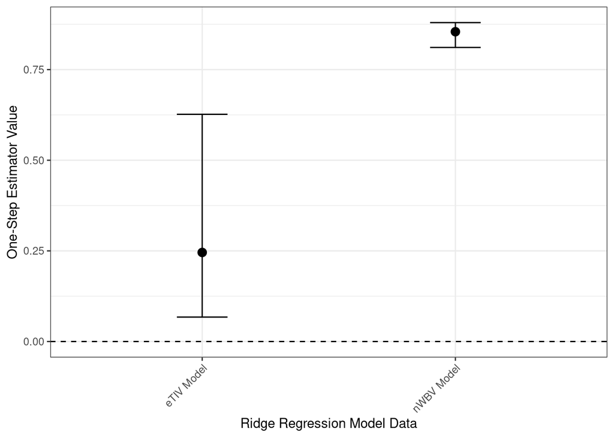

```r
# Finding the median of the one-step estimate value and bounds
result_meds <- results$est %>%
  group_by(metric) %>%
  summarise(
    est = median(est, na.rm = TRUE),
    LB = median(LB, na.rm = TRUE),
    UB = median(UB, na.rm = TRUE)
  )

# Filtering to only the estimates for the eTIV and nWBV estimates
toPlot <- result_meds %>% filter(metric == "eTIV Model" | metric == "nWBV Model")
toPlot_Diff <- result_meds %>% filter(metric == "Diff")

# Plotting results
ggplot(toPlot, aes(x = metric, y = est)) +
  geom_point(position = position_dodge(width = 0.5), size = 3) +
  geom_errorbar(aes(ymin = LB, ymax = UB),
                width = 0.2,
                position = position_dodge(width = 0.5)) +
  theme_bw() +
  theme(axis.text.x = element_text(angle = 45, hjust=1)) +
  geom_hline(yintercept = 0, linetype = "dashed", color = "black")  +
  labs(x = "Ridge Regression Model Data", y = "One-Step Estimator Value")
```

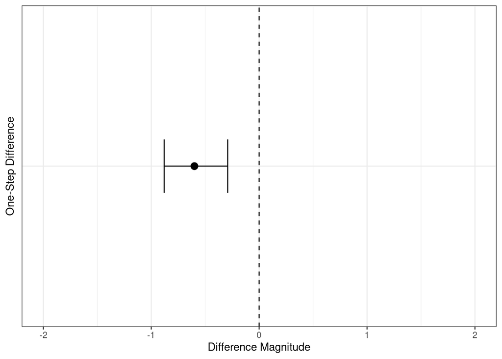

```r
# Plotting one-step difference results
ggplot(toPlot_Diff, aes(x = metric, y = est)) +
  geom_point(position = position_dodge(width = 0.5), size = 3) +
  geom_errorbar(aes(ymin = LB, ymax = UB),
                width = 0.2,
                position = position_dodge(width = 0.5)) +
  theme_bw() +
  theme(axis.ticks.y = element_blank(), axis.text.y = element_blank()) +
  coord_flip() +
  geom_hline(yintercept = 0, linetype = "dashed", color = "black")  +
  ylim(-2,2) +
  labs(x = "One-Step Difference", y = "Difference Magnitude")
```

### 5.2.4 Analysis

Here, even with the inclusion of sample splits to test other scenarios where fold assignment randomly differs, we still see that the inclusion of normalized whole-brain volume (nWBV) instead of estimated total intracranial volume (eTIV) leads to a significantly higher model prediction accuracy for the continuous variable age. This indicates that in neuroimaging prediction studies for age, scientisits should consider using nWBV over eTIV to predict brain age phenotype.

# 6 Random Forest Model Examples

This section seeks to highlight how the *semicor* package can be used to evaluate random forest models in two instances where 1) a model is only trained on cross-fold validation or 2) a model is trained with cross-fold validation and sample splits.

## 6.1 Methods

Here, outside of the random forest model package itself, we create the *helper_ranger* function to help tune and check the validity of our model tuning.

```r
# tuning function
helper_ranger = function(trainDat, outcome, testDat, task){
  # If the tuned model already gives non-constant preds, keep it.
  if (sd(predict(task$model, newdata = data.frame(testDat))$data$response) > 1e-5) {
    return(task$model)
  }

  # Otherwise walk the tried hyperparams (best MSE first) and re-train via mlr
  tune_table <- task$results[order(task$results$mse), ]

  for (i in seq_len(nrow(tune_table))) {
    params <- tune_table[i, ]

    # build an mlr learner with these params
    lrn <- mlr::makeLearner(
      "regr.ranger",
      num.trees       = 250,
      mtry            = params$mtry,
      min.node.size   = params$min.node.size,
      sample.fraction = params$sample.fraction,
      num.threads     = 1,
      respect.unordered.factors = "order"  # or as needed
    )

    # train an mlr model so predict() keeps the same API
    tr_task <- mlr::makeRegrTask(id = "rf_task_retry", data = trainDat, target = outcome)
    wm <- mlr::train(lrn, tr_task)

    # check for non-constant predictions
    if (sd(predict(wm, newdata = data.frame(testDat))$data$response) > 1e-5) {
      return(wm)
    }
  }

  # if everything fails, just return the original
  return(task$model)
}
```

## 6.2 Random Forest Example with only Cross-Fold Validation

### 6.2.1 Training the Model

Here, we test how the inclusion of either eTIV or nWBV in a random forest model impacts model accuracy when predicting age.

```r
# Cleaning data - drop NA before CV
data_clean = OASIS_cross_tbl_df %>% drop_na(Age)

# Assigning folds randomly
folds = 5
data_clean$fold <- sample(rep(1:folds, length.out = nrow(data_clean)))

# Selecting an outcome variable
outcome = "Age"

# Sanity check for fold distribution
table(data_clean$fold)
```

```
##
##  1  2  3  4  5
## 88 87 87 87 87
```

```r
# Creating storage columns
data_clean$preds_eTIV = NA
data_clean$preds_nWBV = NA

# Creating a for loop for 5-fold cross validation
for(i in 1:folds){
  # Assigning data
  test = data_clean %>% filter(fold == i)
  train = data_clean %>% filter(fold != i)

  # Creating model data variables for training
  x_var_eTIV = data.frame(train[, colnames(data_clean) %in% c("eTIV", "ASF", outcome)])
  y_var = data.frame(train[, colnames(data_clean) %in% c("Age")])
  x_var_nWBV = data.frame(train[, colnames(data_clean) %in% c("nWBV", "ASF", outcome)])

  # Creating model variables for prediction
  newx_eTIV = data.frame(test[, colnames(data_clean) %in% c("eTIV", "ASF")])
  newx_nWBV = data.frame(test[, colnames(data_clean) %in% c("nWBV", "ASF")])
  newy = data.frame(test[, colnames(data_clean) %in% c("Age")])

  # Creating random forest tasks
  task_eTIV = makeRegrTask(id = "rf_task", data = x_var_eTIV, target = outcome)
  task_nWBV = makeRegrTask(id = "rf_task", data = x_var_nWBV, target = outcome)

  # Tuning each model
  rfTune_eTIV = tuneRanger(task_eTIV, num.trees = 250, iters = 25, iters.warmup = 10, show.info = FALSE)
  rfTune_nWBV = tuneRanger(task_nWBV, num.trees = 250, iters = 25, iters.warmup = 10, show.info = FALSE)

  # Checking the tuning of each model
  rfTune_eTIV$model = helper_ranger(x_var_eTIV, outcome, newx_eTIV, rfTune_eTIV) # Calling for checking of tuning
  rfTune_nWBV$model = helper_ranger(x_var_nWBV, outcome, newx_nWBV, rfTune_nWBV) # Calling for checking of tuning

  # Getting predictions
  test$preds_eTIV = predict(rfTune_eTIV$model, newdata = newx_eTIV)$data$response
  test$preds_nWBV = predict(rfTune_nWBV$model, newdata = newx_nWBV)$data$response

  # Storing prediction values
  ## Isolating to a singular data frame with only the prediction values and IDs
  test_collapsed <- test %>%
  group_by(ID) %>%
  summarise(
    preds_eTIV = first(na.omit(preds_eTIV)),
    preds_nWBV = first(na.omit(preds_nWBV)),
    .groups = "drop"
  )

  ## Matching the predictions by ID to the original data frame
  data_clean <- data_clean %>%
  left_join(test_collapsed, by = "ID", suffix = c("", "_new"))%>%
  mutate(
    preds_eTIV = ifelse(is.na(preds_eTIV_new), preds_eTIV, preds_eTIV_new),
    preds_nWBV = ifelse(is.na(preds_nWBV_new), preds_nWBV, preds_nWBV_new)
  ) %>%
  select(-ends_with("_new"))
}
```

### 6.2.2 Applying Semicor to Data Predictions

```r
# Gathering the estimates with one sample split
results = sampleSplitOS(as.matrix(data_clean$Age), as.matrix(data_clean$preds_eTIV), as.matrix(data_clean$fold), as.matrix(data_clean$preds_nWBV))

# Here, yhat1 represents the prediction accuracy of the eTIV model and
# yhat2 represents the prediction accuracy of the nWBV model
results$est <- results$est %>% mutate(metric = recode(metric, yhat1 = "eTIV Model", yhat2 = "nWBV Model"))
```

### 6.2.3 Graphing Outputs

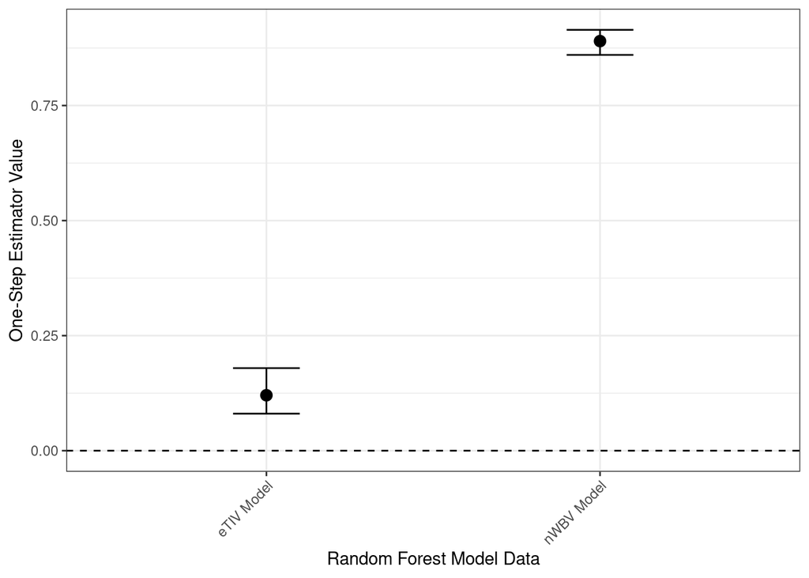

```r
# Subsetting results to only estimates
toPlot = results$est %>% filter(metric == "eTIV Model" | metric == "nWBV Model")
toPlot_Diff =  results$est %>% filter(metric == "Diff")

# Plotting one-step results
ggplot(toPlot, aes(x = metric, y = est)) +
  geom_point(position = position_dodge(width = 0.5), size = 3) +
  geom_errorbar(aes(ymin = LB, ymax = UB),
                width = 0.2,
                position = position_dodge(width = 0.5)) +
  theme_bw() +
  theme(axis.text.x = element_text(angle = 45, hjust=1)) +
  geom_hline(yintercept = 0, linetype = "dashed", color = "black")  +
  labs(x = "Random Forest Model Data", y = "One-Step Estimator Value")
```

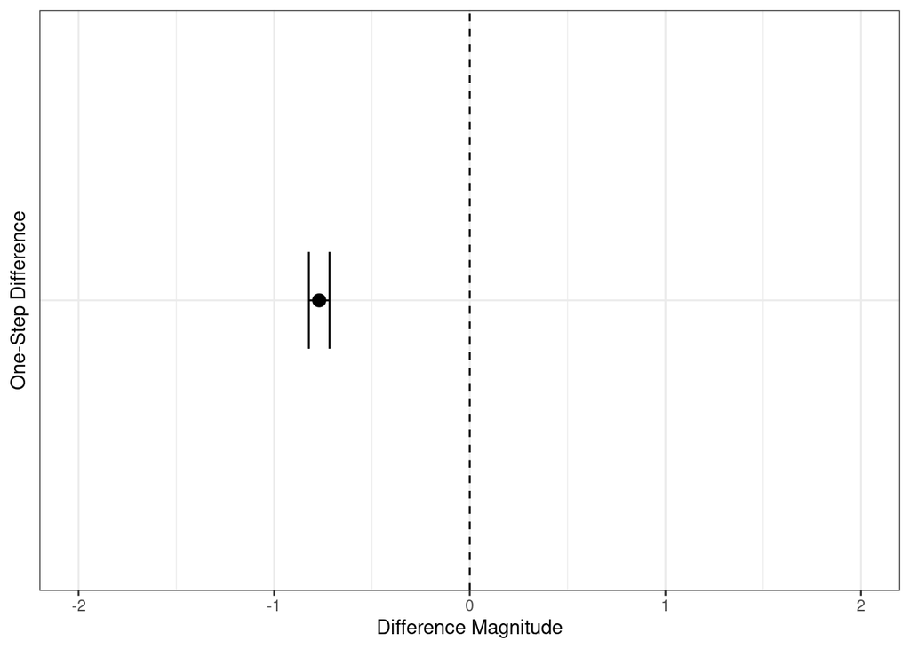

```r
# Plotting one-step difference results
ggplot(toPlot_Diff, aes(x = metric, y = est)) +
  geom_point(position = position_dodge(width = 0.5), size = 3) +
  geom_errorbar(aes(ymin = LB, ymax = UB),
                width = 0.2,
                position = position_dodge(width = 0.5)) +
  theme_bw() +
  theme(axis.ticks.y = element_blank(), axis.text.y = element_blank()) +
  coord_flip() +
  geom_hline(yintercept = 0, linetype = "dashed", color = "black")  +
  ylim(-2,2) +
  labs(x = "One-Step Difference", y = "Difference Magnitude")
```